# Three batter minimum

Exploratory data analysis of the three batter minimum.

Author

[Christian Hicks](https://github.com/hicks017)

Published

April 29, 2025

Modified

May 31, 2025

## Setup

**Packages**

```r
library(readr)
library(dplyr)
library(ggplot2)
library(broom)
library(skimr)
library(gtsummary)
```

**Data**

```r
# Use a flexible route to the file path
if (basename(getwd()) == "explore data") {
  path <- "../resources/data"
} else if (basename(getwd()) == "MLB-rule-changes") {
  path <- "resources/data"
} else {print("Failed to set path")}

df_appearances <- read_csv(file.path(path, "pitcher_appearances.csv"))
df_changes <- read_csv(file.path(path, "pitcher_changes.csv"))
```

## Pitching appearances

**Prepare data**

```r
# Remove duplicates
df_appearances <- distinct(df_appearances)

# Change name for Cleveland to the Guardians
df_appearances <- mutate(df_appearances, team_name = ifelse(
  endsWith(team_name, "Indians"),
  "Cleveland Guardians",
  team_name
))

# Count pitching changes per game by year
tbl_n_per_game_yearly <-
  df_appearances |>
  group_by(game_id, year) |>
  summarise(n = n(), .groups = "drop") |>

  # Add indication of rule change and change year to a factor
  mutate(rule_change = ifelse(year < 2020, FALSE, TRUE)) |>
  mutate(year = factor(year))
```

How many pitchers are teams using in a game over the years?

With a three-batter minimum, the LOOGY and similar specialty roles should mostly be eliminated leading to fewer pitchers used in a game.

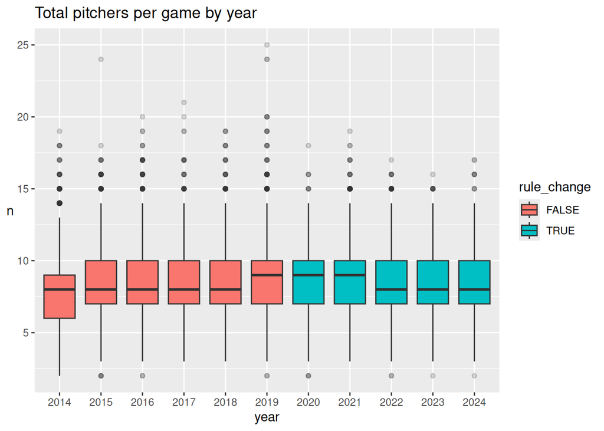

```r
# Plot pitchers per game per year
ggplot(tbl_n_per_game_yearly, aes(x = year, y = n, fill = rule_change)) +
  geom_boxplot(outlier.alpha = 0.2) +
  theme(axis.title.y = element_text(angle=0, vjust = 0.5)) +
  ggtitle("Total pitchers per game by year")
```

```r
# Descriptive statistics
skimr::skim(group_by(select(tbl_n_per_game_yearly, -game_id), year)) |>
  skimr::yank("numeric")
```

**Variable type: numeric**

| skim_variable | year | n_missing | complete_rate | mean | sd | p0 | p25 | p50 | p75 | p100 | hist |
| --- | --- | --- | --- | --- | --- | --- | --- | --- | --- | --- | --- |
| n | 2014 | 0 | 1 | 7.95 | 2.36 | 2 | 6 | 8 | 9 | 19 | ▂▇▅▁▁ |
| n | 2015 | 0 | 1 | 8.22 | 2.40 | 2 | 7 | 8 | 10 | 24 | ▃▇▂▁▁ |
| n | 2016 | 0 | 1 | 8.30 | 2.31 | 2 | 7 | 8 | 10 | 20 | ▁▇▂▁▁ |
| n | 2017 | 0 | 1 | 8.44 | 2.20 | 3 | 7 | 8 | 10 | 21 | ▂▇▂▁▁ |
| n | 2018 | 0 | 1 | 8.72 | 2.30 | 3 | 7 | 8 | 10 | 19 | ▂▇▅▁▁ |
| n | 2019 | 0 | 1 | 8.82 | 2.44 | 2 | 7 | 9 | 10 | 25 | ▂▇▁▁▁ |
| n | 2020 | 0 | 1 | 8.87 | 2.26 | 2 | 7 | 9 | 10 | 18 | ▁▇▇▂▁ |
| n | 2021 | 0 | 1 | 8.87 | 2.22 | 3 | 7 | 9 | 10 | 19 | ▂▇▅▁▁ |
| n | 2022 | 0 | 1 | 8.59 | 2.07 | 2 | 7 | 8 | 10 | 17 | ▁▇▇▁▁ |
| n | 2023 | 0 | 1 | 8.49 | 1.99 | 2 | 7 | 8 | 10 | 16 | ▁▅▇▂▁ |
| n | 2024 | 0 | 1 | 8.52 | 1.96 | 2 | 7 | 8 | 10 | 17 | ▁▇▇▁▁ |

```r
# t test
t.test(n ~ rule_change, data = tbl_n_per_game_yearly) |>
  tidy() |>
  rename(pre_2020 = estimate1, post_2020 = estimate2)
```

| estimate | pre_2020 | post_2020 | statistic | p.value | parameter | conf.low | conf.high | method | alternative |
| --- | --- | --- | --- | --- | --- | --- | --- | --- | --- |
| -0.2289107 | 8.410784 | 8.639695 | -8.142478 | 0 | 24254.16 | -0.2840142 | -0.1738072 | Welch Two Sample t-test | two.sided |

Number of pitchers used by both teams has increased since 2020, but the magnitude was small.

## Mid-inning pitching changes

How many pitching changes occurred during inning play in a game over the years?

**Prepare data**

```r
# Change name for Cleveland to the Guardians
df_changes <- mutate(df_changes, team_name = ifelse(
  endsWith(team_name, "Indians"),
  "Cleveland Guardians",
  team_name
))

# Count pitching changes per game by year
tbl_changes_per_game_yearly <-
  df_changes |>
  group_by(game_id, year) |>
  summarise(n = n(), .groups = "drop") |>

  # Input games without a mid-inning pitching change
  mutate(event = TRUE) |>
  right_join(
    df_appearances |> select(game_id, year) |> distinct(),
    by = c("game_id", "year")
  ) |>
  mutate(n = ifelse(is.na(event), 0, n)) |>
  select(-event) |>

  # Add indication of rule change and change year to a factor
  mutate(rule_change = ifelse(year < 2020, FALSE, TRUE)) |>
  mutate(year = factor(year))
```

A three-batter minimum means there’s less opportunity to call in a pitcher for a single batter, which should decrease the number of pitching changes that occur in the middle of an inning.

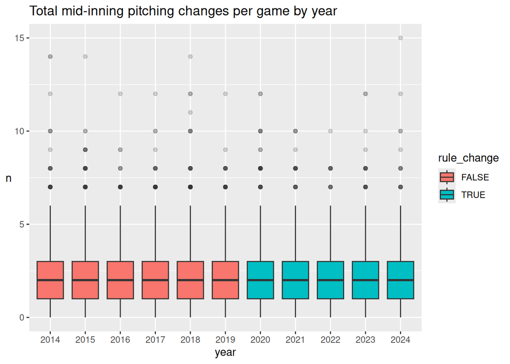

```r
# Plot pitchers per game per year
ggplot(tbl_changes_per_game_yearly, aes(x = year, y = n, fill = rule_change)) +
  geom_boxplot(outlier.alpha = 0.2) +
  theme(axis.title.y = element_text(angle=0, vjust = 0.5)) +
  ggtitle("Total mid-inning pitching changes per game by year")
```

```r
# Descriptive statistics
skimr::skim(group_by(select(tbl_changes_per_game_yearly, -game_id), year)) |>
  skimr::yank("numeric")
```

**Variable type: numeric**

| skim_variable | year | n_missing | complete_rate | mean | sd | p0 | p25 | p50 | p75 | p100 | hist |
| --- | --- | --- | --- | --- | --- | --- | --- | --- | --- | --- | --- |
| n | 2014 | 0 | 1 | 2.04 | 1.55 | 0 | 1 | 2 | 3 | 14 | ▇▃▁▁▁ |
| n | 2015 | 0 | 1 | 2.19 | 1.58 | 0 | 1 | 2 | 3 | 14 | ▇▅▁▁▁ |
| n | 2016 | 0 | 1 | 2.10 | 1.47 | 0 | 1 | 2 | 3 | 12 | ▇▃▁▁▁ |
| n | 2017 | 0 | 1 | 2.21 | 1.53 | 0 | 1 | 2 | 3 | 12 | ▇▃▁▁▁ |
| n | 2018 | 0 | 1 | 2.23 | 1.59 | 0 | 1 | 2 | 3 | 14 | ▇▅▁▁▁ |
| n | 2019 | 0 | 1 | 2.20 | 1.53 | 0 | 1 | 2 | 3 | 12 | ▇▃▁▁▁ |
| n | 2020 | 0 | 1 | 2.50 | 1.79 | 0 | 1 | 2 | 3 | 12 | ▇▃▁▁▁ |
| n | 2021 | 0 | 1 | 1.99 | 1.46 | 0 | 1 | 2 | 3 | 10 | ▇▃▁▁▁ |
| n | 2022 | 0 | 1 | 1.94 | 1.39 | 0 | 1 | 2 | 3 | 10 | ▇▃▁▁▁ |
| n | 2023 | 0 | 1 | 2.02 | 1.46 | 0 | 1 | 2 | 3 | 12 | ▇▃▁▁▁ |
| n | 2024 | 0 | 1 | 2.01 | 1.45 | 0 | 1 | 2 | 3 | 15 | ▇▁▁▁▁ |

```r
# t test
t.test(n ~ rule_change, data = tbl_changes_per_game_yearly) |>
  tidy() |>
  rename(pre_2020 = estimate1, post_2020 = estimate2)
```

| estimate | pre_2020 | post_2020 | statistic | p.value | parameter | conf.low | conf.high | method | alternative |
| --- | --- | --- | --- | --- | --- | --- | --- | --- | --- |
| 0.1298124 | 2.16231 | 2.032498 | 6.750544 | 0 | 23418.79 | 0.0921205 | 0.1675043 | Welch Two Sample t-test | two.sided |

The number of mid-inning pitching changes decreased since 2020, but the magnitude was small.

## Games with unscheduled pauses

A mid-inning pitching change would add a pause in play that was not already scheduled, such as pauses in between innings.

What proportion of games had these added pauses?

### 1 or more pauses

**Prepare data**

```r
# Indicate games with n pauses
tbl_changes_per_game_yearly <- mutate(
  tbl_changes_per_game_yearly,
  pause_01 = ifelse(n > 0, TRUE, FALSE),
  pause_02 = ifelse(n > 1, TRUE, FALSE),
  pause_03 = ifelse(n > 2, TRUE, FALSE)
)

# Summarize by year
skimr::skim(select(group_by(tbl_changes_per_game_yearly, year), pause_01, year)) |>
  skimr::yank("logical")
```

**Variable type: logical**

| skim_variable | year | n_missing | complete_rate | mean | count |
| --- | --- | --- | --- | --- | --- |
| pause_01 | 2014 | 0 | 1 | 0.87 | TRU: 2120, FAL: 310 |
| pause_01 | 2015 | 0 | 1 | 0.88 | TRU: 2140, FAL: 289 |
| pause_01 | 2016 | 0 | 1 | 0.88 | TRU: 2139, FAL: 289 |
| pause_01 | 2017 | 0 | 1 | 0.89 | TRU: 2172, FAL: 258 |
| pause_01 | 2018 | 0 | 1 | 0.88 | TRU: 2139, FAL: 292 |
| pause_01 | 2019 | 0 | 1 | 0.89 | TRU: 2153, FAL: 276 |
| pause_01 | 2020 | 0 | 1 | 0.93 | TRU: 832, FAL: 66 |
| pause_01 | 2021 | 0 | 1 | 0.86 | TRU: 2095, FAL: 334 |
| pause_01 | 2022 | 0 | 1 | 0.87 | TRU: 2113, FAL: 317 |
| pause_01 | 2023 | 0 | 1 | 0.88 | TRU: 2127, FAL: 303 |
| pause_01 | 2024 | 0 | 1 | 0.87 | TRU: 2108, FAL: 321 |

**Prepare data**

```r
# Test result by rule change
gtsummary::tbl_summary(
  data = tbl_changes_per_game_yearly,
  include = pause_01,
  by = rule_change
) |>
  gtsummary::  modify_spanning_header(all_stat_cols() ~ "**Rule change**") |>
  gtsummary::add_p()
```

| **Characteristic** | **Rule change** **FALSE** N = 14,577<sup>1</sup> | **Rule change** **TRUE** N = 10,616<sup>1</sup> | **p-value**<sup>2</sup> |  |
| --- | --- | --- | --- | --- |
| pause_01 | 12,863 (88%) | 9,275 (87%) |  | 0.036 |

<sup>1</sup> n (%)  
<sup>2</sup> Pearson’s Chi-squared test

There was a -1% change in games with any added pauses in play due to mid-inning pitching changes.

### 2 or more pauses

```r
# Summarize by year
skimr::skim(select(group_by(tbl_changes_per_game_yearly, year), pause_02, year)) |>
  skimr::yank("logical")
```

**Variable type: logical**

| skim_variable | year | n_missing | complete_rate | mean | count |
| --- | --- | --- | --- | --- | --- |
| pause_02 | 2014 | 0 | 1 | 0.59 | TRU: 1428, FAL: 1002 |
| pause_02 | 2015 | 0 | 1 | 0.63 | TRU: 1535, FAL: 894 |
| pause_02 | 2016 | 0 | 1 | 0.62 | TRU: 1501, FAL: 927 |
| pause_02 | 2017 | 0 | 1 | 0.64 | TRU: 1546, FAL: 884 |
| pause_02 | 2018 | 0 | 1 | 0.65 | TRU: 1578, FAL: 853 |
| pause_02 | 2019 | 0 | 1 | 0.64 | TRU: 1554, FAL: 875 |
| pause_02 | 2020 | 0 | 1 | 0.69 | TRU: 624, FAL: 274 |
| pause_02 | 2021 | 0 | 1 | 0.59 | TRU: 1427, FAL: 1002 |
| pause_02 | 2022 | 0 | 1 | 0.57 | TRU: 1394, FAL: 1036 |
| pause_02 | 2023 | 0 | 1 | 0.60 | TRU: 1458, FAL: 972 |
| pause_02 | 2024 | 0 | 1 | 0.60 | TRU: 1457, FAL: 972 |

```r
# Test result by rule change
gtsummary::tbl_summary(
  data = tbl_changes_per_game_yearly,
  include = pause_02,
  by = rule_change
) |>
  gtsummary::  modify_spanning_header(all_stat_cols() ~ "**Rule change**") |>
  gtsummary::add_p()
```

| **Characteristic** | **Rule change** **FALSE** N = 14,577<sup>1</sup> | **Rule change** **TRUE** N = 10,616<sup>1</sup> | **p-value**<sup>2</sup> |  |
| --- | --- | --- | --- | --- |
| pause_02 | 9,142 (63%) | 6,360 (60%) |  | <0.001 |

<sup>1</sup> n (%)  
<sup>2</sup> Pearson’s Chi-squared test

There was a -3% change in games with 2 or more added pauses in play due to mid-inning pitching changes.

### 3 or more pauses

```r
# Summarize by year
skimr::skim(select(group_by(tbl_changes_per_game_yearly, year), pause_03, year)) |>
  skimr::yank("logical")
```

**Variable type: logical**

| skim_variable | year | n_missing | complete_rate | mean | count |
| --- | --- | --- | --- | --- | --- |
| pause_03 | 2014 | 0 | 1 | 0.31 | FAL: 1672, TRU: 758 |
| pause_03 | 2015 | 0 | 1 | 0.36 | FAL: 1547, TRU: 882 |
| pause_03 | 2016 | 0 | 1 | 0.34 | FAL: 1606, TRU: 822 |
| pause_03 | 2017 | 0 | 1 | 0.37 | FAL: 1532, TRU: 898 |
| pause_03 | 2018 | 0 | 1 | 0.38 | FAL: 1507, TRU: 924 |
| pause_03 | 2019 | 0 | 1 | 0.37 | FAL: 1526, TRU: 903 |
| pause_03 | 2020 | 0 | 1 | 0.40 | FAL: 538, TRU: 360 |
| pause_03 | 2021 | 0 | 1 | 0.31 | FAL: 1674, TRU: 755 |
| pause_03 | 2022 | 0 | 1 | 0.30 | FAL: 1708, TRU: 722 |
| pause_03 | 2023 | 0 | 1 | 0.31 | FAL: 1684, TRU: 746 |
| pause_03 | 2024 | 0 | 1 | 0.32 | FAL: 1648, TRU: 781 |

```r
# Test result by rule change
gtsummary::tbl_summary(
  data = tbl_changes_per_game_yearly,
  include = pause_03,
  by = rule_change
) |>
  gtsummary::  modify_spanning_header(all_stat_cols() ~ "**Rule change**") |>
  gtsummary::add_p()
```

| **Characteristic** | **Rule change** **FALSE** N = 14,577<sup>1</sup> | **Rule change** **TRUE** N = 10,616<sup>1</sup> | **p-value**<sup>2</sup> |  |
| --- | --- | --- | --- | --- |
| pause_03 | 5,187 (36%) | 3,364 (32%) |  | <0.001 |

<sup>1</sup> n (%)  
<sup>2</sup> Pearson’s Chi-squared test

There was a -4% change in games with 3 or more added pauses in play due to mid-inning pitching changes.

**Overall conclusion:** Although reductions of games with added pauses are statistically significant and of greater magnitude as the minimum threshold increases, the real-world impact is likely small.

Note: Could just show `pause_01` through `pause_03` on same table.